# R Notebook

```r
cc <- read.csv('consumer_complaints.csv')
# View(cc)
glimpse(cc)
```

```
Rows: 14,000
Columns: 16
$ X.ID                     <int> 1615767, 654223, 1143398, 1303679, 1627370, 1390231, 1946542, 1414270, 31083…
$ Company                  <chr> "PHH Mortgage", "Ocwen", "Southwest Credit Systems, L.P.", "Continental Fina…
$ Product                  <chr> "Mortgage", "Mortgage", "Debt collection", "Credit card", "Credit reporting"…
$ Issue                    <chr> "Loan servicing, payments, escrow account", "Loan servicing, payments, escro…
$ State                    <chr> "FL", "NC", "MO", "WA", "VA", "IL", "FL", "OK", "CA", "CA", "AZ", "MO", "NY"…
$ Submitted.via            <chr> "Web", "Web", "Web", "Web", "Web", "Web", "Web", "Web", "Web", "Web", "Email…
$ Date.received            <chr> "10/20/2015", "3/1/2014", "4/12/2014", "03/26/2015", "10/27/2015", "05/23/20…
$ Date.resolved            <chr> "10/20/2015", "3/1/2014", "4/12/2014", "03/26/2015", "10/27/2015", "05/23/20…
$ Timely.response.         <chr> "Yes", "Yes", "Yes", "Yes", "Yes", "Yes", "Yes", "Yes", "Yes", "Yes", "Yes",…
$ Consumer.disputed.       <chr> "No", "No", "No", "No", "No", "No", "No", "No", "No", "No", "No", "No", "Yes…
$ state.name               <chr> "Florida", "North Carolina", "Missouri", "Washington", "Virginia", "Illinois…
$ Date.received.1          <chr> "10/20/2015", "1/3/2014", "12/4/2014", "3/26/2015", "10/27/2015", "5/23/2015…
$ Date.resolved.1          <chr> "10/20/2015", "1/3/2014", "12/4/2014", "3/26/2015", "10/27/2015", "5/23/2015…
$ Resolution.time.in.days. <int> 0, 0, 0, 0, 0, 0, 1, 0, 0, 0, 5, 0, 0, 29, 0, 0, 0, 2, 0, 65, 5, 0, 0, 0, 4,…
$ Year                     <int> 2015, 2014, 2014, 2015, 2015, 2015, 2016, 2015, 2013, 2016, 2016, 2014, 2013…
$ QTR..US.FLY.             <chr> "Q4", "Q1", "Q4", "Q1", "Q4", "Q2", "Q2", "Q2", "Q1", "Q1", "Q1", "Q4", "Q4"…
```

2. Numeric: Resolution.time.in.days, Year Categorical: X.ID

```r
str(cc$Consumer.disputed.)
```

```
 chr [1:14000] "No" "No" "No" "No" "No" "No" "No" "No" "No" "No" "No" "No" "Yes" "No" "No" "No" "Yes" "No" ...
```

```r
cc$Consumer.disputed. <- factor(cc$Consumer.disputed.)
levels(cc$Consumer.disputed.)
```

```
[1] "No"  "Yes"
```

```r
table(cc$Consumer.disputed.)
```

```
   No   Yes
10862  3138
```

```r
cc %>% group_by(Consumer.disputed.) %>%
  summarise(Count = n()/14000)
```

| Consumer.disputed. | Count |
| --- | --- |
| No | 0.7758571 |
| Yes | 0.2241429 |

3.a. Consumer.disputed. variable is of type chr, then I converted it to factor. b. Now it has 2 levels: Yes or No. The data is imbalanced, out of 14,000 complaints only 3138 (22.4%) disputed.

```r
names(cc)
```

```
 [1] "X.ID"                     "Company"                  "Product"
 [4] "Issue"                    "State"                    "Submitted.via"
 [7] "Date.received"            "Date.resolved"            "Timely.response."
[10] "Consumer.disputed."       "state.name"               "Date.received.1"
[13] "Date.resolved.1"          "Resolution.time.in.days." "Year"
[16] "QTR..US.FLY."
```

```r
cc <- cc %>% rename(Resolution.time.in.days = Resolution.time.in.days.,
              Timely.response=Timely.response.,
              Consumer.disputed=Consumer.disputed.,
              Quarter = QTR..US.FLY.)
```

4. I removed dots from variables that had them at the end, and renamed QTR..US.FLY. to Quarter.

```r
sapply(cc, function(x) length(unique(x)))
```

```
                   X.ID                 Company                 Product                   Issue
                  14000                    1050                      12                      81
                  State           Submitted.via           Date.received           Date.resolved
                     60                       5                    1370                    1322
        Timely.response       Consumer.disputed              state.name         Date.received.1
                      2                       2                      52                    1370
        Date.resolved.1 Resolution.time.in.days                    Year                 Quarter
                   1322                      77                       4                       4
```

5. After examining number of unique values in each column, we observe that a few columns contain more than 100 distinct values. Specifically, there are 14,000 unique ID records, 1,050 companies, and over 1,300 date values.

```r
cc <- cc %>% select(-X.ID, -Company, -Date.received, -Date.resolved, -Date.received.1, -Date.resolved.1)

str(cc)
```

```
'data.frame':   14000 obs. of  10 variables:
 $ Product                : chr  "Mortgage" "Mortgage" "Debt collection" "Credit card" ...
 $ Issue                  : chr  "Loan servicing, payments, escrow account" "Loan servicing, payments, escrow account" "Loan modification,collection,foreclosure" "Billing statement" ...
 $ State                  : chr  "FL" "NC" "MO" "WA" ...
 $ Submitted.via          : chr  "Web" "Web" "Web" "Web" ...
 $ Timely.response        : chr  "Yes" "Yes" "Yes" "Yes" ...
 $ Consumer.disputed      : Factor w/ 2 levels "No","Yes": 1 1 1 1 1 1 1 1 1 1 ...
 $ state.name             : chr  "Florida" "North Carolina" "Missouri" "Washington" ...
 $ Resolution.time.in.days: int  0 0 0 0 0 0 1 0 0 0 ...
 $ Year                   : int  2015 2014 2014 2015 2015 2015 2016 2015 2013 2016 ...
 $ Quarter                : chr  "Q4" "Q1" "Q4" "Q1" ...
```

```r
summary(cc)
```

```
   Product             Issue              State           Submitted.via      Timely.response
 Length:14000       Length:14000       Length:14000       Length:14000       Length:14000
 Class :character   Class :character   Class :character   Class :character   Class :character
 Mode  :character   Mode  :character   Mode  :character   Mode  :character   Mode  :character



 Consumer.disputed  state.name        Resolution.time.in.days      Year        Quarter
 No :10862         Length:14000       Min.   : -1.000         Min.   :2013   Length:14000
 Yes: 3138         Class :character   1st Qu.:  0.000         1st Qu.:2014   Class :character
                   Mode  :character   Median :  0.000         Median :2015   Mode  :character
                                      Mean   :  2.006         Mean   :2015
                                      3rd Qu.:  2.000         3rd Qu.:2016
                                      Max.   :286.000         Max.   :2016
```

```r
table(cc$State)
```

```
       AA   AE   AK   AL   AP   AR   AS   AZ   CA   CO   CT   DC   DE   FL   GA   GU   HI   IA   ID   IL   IN
 110    1    5   19  135    4   62    1  313 1977  251  161   98   80 1255  577    1   39   56   51  500  137
  KS   KY   LA   MA   MD   ME   MI   MN   MO   MP   MS   MT   NC   ND   NE   NH   NJ   NM   NV   NY   OH   OK
  78   99  149  292  408   47  373  174  171    1   77   19  443    7   54   65  518   75  171  996  463   93
  OR   PA   PR   RI   SC   SD   TN   TX   UT   VA   VI   VT   WA   WI   WV   WY
 177  511   26   64  194   26  238 1040   77  480    8   29  303  178   32   11
```

```r
cc <- cc %>% select(-state.name) %>%
  filter(Resolution.time.in.days>=0)

str(cc)
```

```
'data.frame':   13997 obs. of  9 variables:
 $ Product                : chr  "Mortgage" "Mortgage" "Debt collection" "Credit card" ...
 $ Issue                  : chr  "Loan servicing, payments, escrow account" "Loan servicing, payments, escrow account" "Loan modification,collection,foreclosure" "Billing statement" ...
 $ State                  : chr  "FL" "NC" "MO" "WA" ...
 $ Submitted.via          : chr  "Web" "Web" "Web" "Web" ...
 $ Timely.response        : chr  "Yes" "Yes" "Yes" "Yes" ...
 $ Consumer.disputed      : Factor w/ 2 levels "No","Yes": 1 1 1 1 1 1 1 1 1 1 ...
 $ Resolution.time.in.days: int  0 0 0 0 0 0 1 0 0 0 ...
 $ Year                   : int  2015 2014 2014 2015 2015 2015 2016 2015 2013 2016 ...
 $ Quarter                : chr  "Q4" "Q1" "Q4" "Q1" ...
```

6. a.Examining the results of the summary() function, we notice an impossible negative number for the resolution date. Additionally, there are two overlapping columns: State and State_name. b.Before that, when counting unique values by column, we observed that the State column had 60 unique values, while the State_name column had 52. Upon examining the values, it appears that the State column includes more detailed information, possibly encompassing territories and military postal codes. We can also keep Year, Resolution.time.in.days, and Quarter, which are related to the removed columns date_received, and date_resolved.

```r
cc <- cc %>%
  mutate(Year = cut(Year,
                    breaks = c(2012, 2014, 2016),
                    labels = c("Earlier period", "Later period"),
                    right = TRUE))

str(cc)
```

```
'data.frame':   13997 obs. of  9 variables:
 $ Product                : chr  "Mortgage" "Mortgage" "Debt collection" "Credit card" ...
 $ Issue                  : chr  "Loan servicing, payments, escrow account" "Loan servicing, payments, escrow account" "Loan modification,collection,foreclosure" "Billing statement" ...
 $ State                  : chr  "FL" "NC" "MO" "WA" ...
 $ Submitted.via          : chr  "Web" "Web" "Web" "Web" ...
 $ Timely.response        : chr  "Yes" "Yes" "Yes" "Yes" ...
 $ Consumer.disputed      : Factor w/ 2 levels "No","Yes": 1 1 1 1 1 1 1 1 1 1 ...
 $ Resolution.time.in.days: int  0 0 0 0 0 0 1 0 0 0 ...
 $ Year                   : Factor w/ 2 levels "Earlier period",..: 2 1 1 2 2 2 2 2 1 2 ...
 $ Quarter                : chr  "Q4" "Q1" "Q4" "Q1" ...
```

```r
table(cc$Resolution.time.in.days)
```

```
   0    1    2    3    4    5    6    7    8    9   10   11   12   13   14   15   16   17   18   19   20   21
8316 1616 1122  844  491  473  318  222   83   35   47   37   21   18   18   18    9   10   16   15   12   22
  22   23   24   25   26   27   28   29   30   31   32   33   34   35   36   37   38   39   40   41   42   43
   9    6   13    6    7    2   10   16    5    9   14    9    9   11   12    3    3    7    3    8    3    8
  45   46   47   48   49   50   51   52   55   56   57   60   61   63   64   65   66   67   68   70   72   76
   5    2    5    1    5    3    3    1    6    2    1    2    4    2    1    2    1    1    1    1    1    1
  77   79   83   90   93   95   98  106  151  286
   1    1    1    1    1    1    1    1    1    1
```

```r
non_zero_values <- cc$Resolution.time.in.days[cc$Resolution.time.in.days > 0]
breaks <- quantile(non_zero_values, probs = seq(0, 1, length.out = 3))

breaks <- c(0, breaks)

cc$Resolution.time.in.days <- cut(cc$Resolution.time.in.days, breaks = breaks, labels = c("low", "medium", "high"), include.lowest = TRUE)


table(cc$Resolution.time.in.days)
```

```
   low medium   high
  9932   1966   2099
```

7. a.The Year column contains four unique values: 2013, 2014, 2015, and 2016. For binning, we can group them into two categories: ‘Earlier period’ for 2013 and 2014, and ‘Later period’ for 2015 and 2016.
2. The Resolution_time variable contains a significant number of zeros (8,316) along with other values. This imbalance caused issues when using the equal frequency method for binning. To address this, I first filtered out the non-zero values to determine the breaks within the data. Then, I added zero to this group. As a result, we have three groups: low, medium, and high.

```r
length(unique(cc$Product))
```

```
[1] 12
```

```r
top_6_Product <- cc %>%
  count(Product, sort = TRUE) %>%
  slice(1:6) %>%
  select(Product)

length(unique(cc$Issue))
```

```
[1] 81
```

```r
top_7_Issue <- cc %>%
  count(Issue, sort = TRUE) %>%
  slice(1:7) %>%
  select(Issue)

length(unique(cc$State))
```

```
[1] 60
```

```r
top_10_State <- cc %>%
  count(State, sort = TRUE) %>%
  slice(1:10) %>%
  select(State)

cc <- cc %>% filter(Product %in% top_6_Product$Product &
                Issue %in% top_7_Issue$Issue &
                State %in% top_10_State$State)

cc <- cc %>%
  mutate(Issue = case_when(
    Issue == "Account opening, closing, or management" ~ "Account Management",
    Issue == "Application, originator, mortgage broker" ~ "Mortgage Application",
    Issue == "Communication tactics" ~ "Communication",
    Issue == "Credit reporting company's investigation" ~ "Credit Investigation",
    Issue == "Deposits and withdrawals" ~ "Transactions",
    Issue == "Loan modification,collection,foreclosure" ~ "Loan Modification",
    Issue == "Loan servicing, payments, escrow account" ~ "Loan Servicing",
    TRUE ~ Issue
  ))

nrow(cc)
```

```
[1] 4110
```

8. 1. The Company variable was nearly removed from the dataset in stage 5.
2. The Product column has 12 unique values, but we will use only the 6 most common ones.
3. The Issue column contains 81 unique values, and we will use only the 7 most common ones. Also changed these 7 values to the shorter names.
4. The State column has 60 unique values, and we will use the 10 most common ones.
5. After reducing the unique levels, the dataset now contains 4110 rows.

```r
str(cc)
```

```
'data.frame':   4110 obs. of  9 variables:
 $ Product                : chr  "Mortgage" "Mortgage" "Credit reporting" "Debt collection" ...
 $ Issue                  : chr  "Loan Servicing" "Mortgage Application" "Credit Investigation" "Loan Modification" ...
 $ State                  : chr  "FL" "FL" "CA" "NY" ...
 $ Submitted.via          : chr  "Web" "Web" "Web" "Email" ...
 $ Timely.response        : chr  "Yes" "Yes" "Yes" "Yes" ...
 $ Consumer.disputed      : Factor w/ 2 levels "No","Yes": 1 1 1 2 1 1 1 1 1 2 ...
 $ Resolution.time.in.days: Factor w/ 3 levels "low","medium",..: 1 1 1 1 1 3 3 1 3 1 ...
 $ Year                   : Factor w/ 2 levels "Earlier period",..: 2 2 2 1 2 1 2 2 2 1 ...
 $ Quarter                : chr  "Q4" "Q2" "Q1" "Q4" ...
```

```r
cc$Product <- as.factor(cc$Product)
cc$Issue <- as.factor(cc$Issue)
cc$State <- as.factor(cc$State)
cc$Submitted.via <- as.factor(cc$Submitted.via)
cc$Timely.response <- as.factor(cc$Timely.response)
cc$Year <- as.factor(cc$Year)
cc$Quarter <- as.factor(cc$Quarter)

set.seed(79)
cc.index <- sample(c(1:nrow(cc)), nrow(cc)*0.6)
cc_train.df <- cc[cc.index, ]
cc_valid.df <- cc[-cc.index, ]
```

9. After converting all variables to factor type, I partitioned the data into training(60%) and validation(40%) sets.

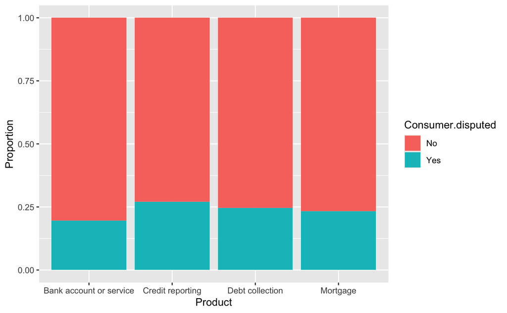

```r
library(ggplot2)

ggplot(cc_train.df, aes(x = Product, fill = Consumer.disputed)) +
    geom_bar(position = 'fill') +
  labs(x = "Product", y = "Proportion")
```

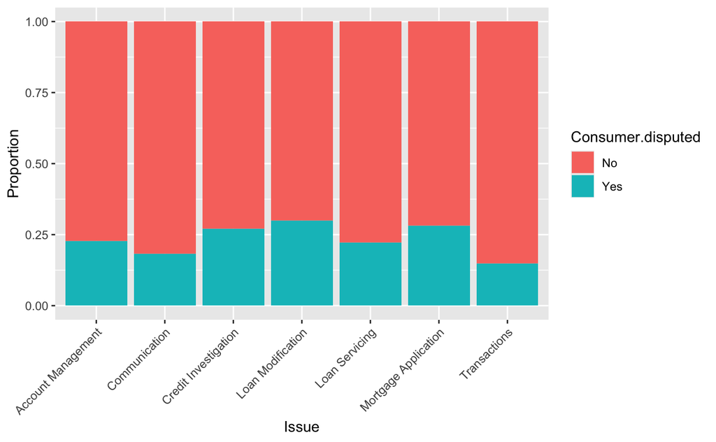

```r
ggplot(cc_train.df, aes(x = Issue, fill = Consumer.disputed)) +
    geom_bar(position = 'fill') +
  # coord_flip() +
  theme(axis.text.x = element_text(angle = 45, hjust = 1)) +
  labs(x = "Issue", y = "Proportion")
```

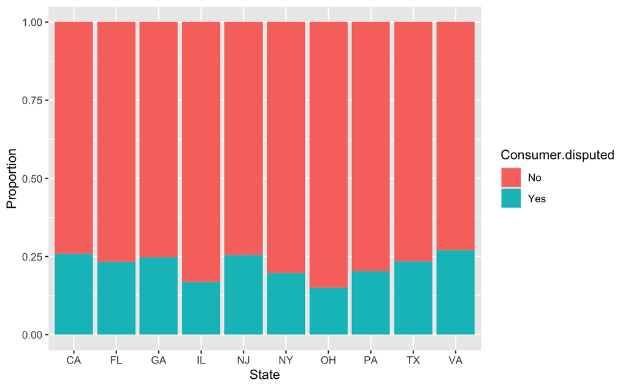

```r
ggplot(cc_train.df, aes(x = State, fill = Consumer.disputed)) +
    geom_bar(position = 'fill') +
  labs(x = "State", y = "Proportion")
```

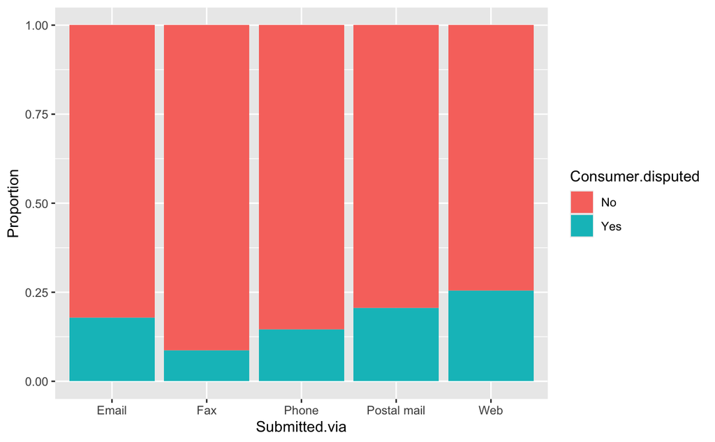

```r
ggplot(cc_train.df, aes(x = Submitted.via, fill = Consumer.disputed)) +
    geom_bar(position = 'fill') +
  labs(x = "Submitted.via", y = "Proportion")
```

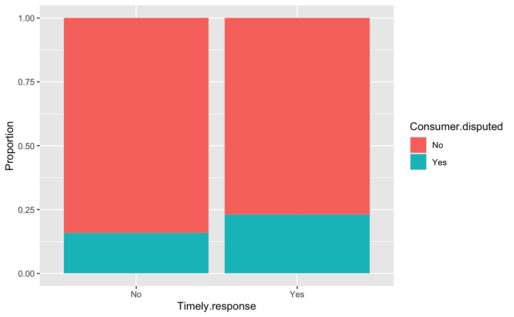

```r
ggplot(cc_train.df, aes(x = Timely.response, fill = Consumer.disputed)) +
    geom_bar(position = 'fill') +
  labs(x = "Timely.response", y = "Proportion")
```

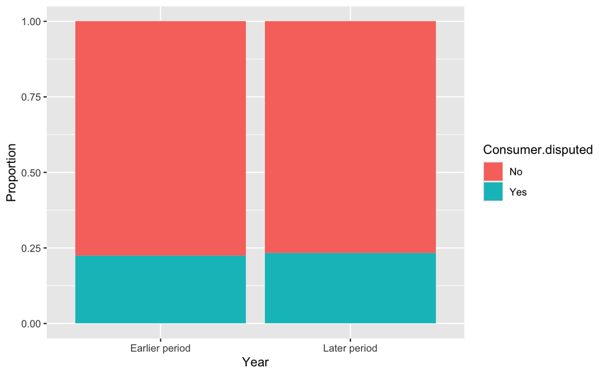

```r
ggplot(cc_train.df, aes(x = Year, fill = Consumer.disputed)) +
    geom_bar(position = 'fill') +
  labs(x = "Year", y = "Proportion")
```

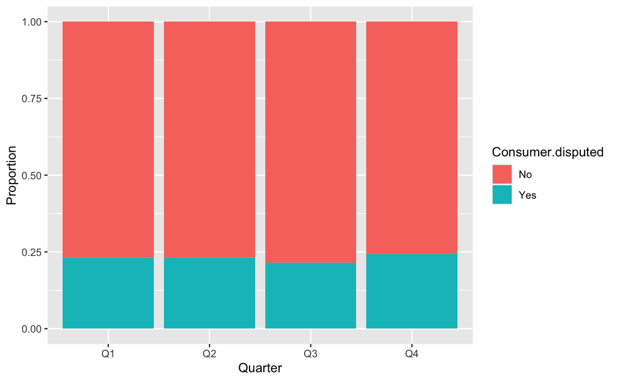

```r
ggplot(cc_train.df, aes(x = Quarter, fill = Consumer.disputed)) +
    geom_bar(position = 'fill') +
  labs(x = "Quarter", y = "Proportion")
```

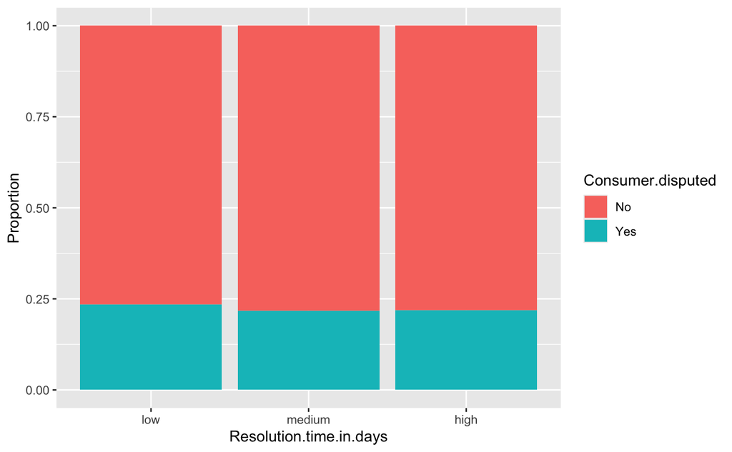

```r
ggplot(cc_train.df, aes(x = Resolution.time.in.days, fill = Consumer.disputed)) +
    geom_bar(position = 'fill') +
  labs(x = "Resolution.time.in.days", y = "Proportion")
```

10. a.For the Year variable, we observed a similar proportion between time periods and whether consumers disputed or not. The same applies to the Quarter variable, with only a small difference in the third quarter. Timely.response showed better result with noticeable differences between values compared to Resolution.time.in.days. For the remaining variables, we can see distinct differences between categories.
2. I will remove Resolution.time.in.days, because of the imbalance of values in dataset.

```r
cc_train.df <- cc_train.df %>% select(-Year, -Quarter, -Resolution.time.in.days)
str(cc_train.df)
```

```
'data.frame':   2466 obs. of  6 variables:
 $ Product          : Factor w/ 4 levels "Bank account or service",..: 3 1 4 3 4 3 1 3 3 4 ...
 $ Issue            : Factor w/ 7 levels "Account Management",..: 2 1 5 4 5 4 1 2 2 5 ...
 $ State            : Factor w/ 10 levels "CA","FL","GA",..: 2 5 2 8 8 5 4 3 9 1 ...
 $ Submitted.via    : Factor w/ 5 levels "Email","Fax",..: 5 5 5 4 5 4 1 5 5 5 ...
 $ Timely.response  : Factor w/ 2 levels "No","Yes": 2 2 2 2 2 2 2 2 2 2 ...
 $ Consumer.disputed: Factor w/ 2 levels "No","Yes": 1 1 1 2 1 1 1 1 1 1 ...
```

```r
library(e1071)
cc.nb <- naiveBayes(Consumer.disputed ~.,data = cc_train.df)
cc.nb
```

```
Naive Bayes Classifier for Discrete Predictors

Call:
naiveBayes.default(x = X, y = Y, laplace = laplace)

A-priori probabilities:
Y
       No       Yes
0.7704785 0.2295215

Conditional probabilities:
     Product
Y     Bank account or service Credit reporting Debt collection   Mortgage
  No               0.27210526       0.08368421      0.22473684 0.41947368
  Yes              0.22261484       0.10424028      0.24558304 0.42756184

     Issue
Y     Account Management Communication Credit Investigation Loan Modification Loan Servicing
  No          0.15947368    0.11105263           0.08368421        0.11368421     0.34421053
  Yes         0.15724382    0.08303887           0.10424028        0.16254417     0.32862191
     Issue
Y     Mortgage Application Transactions
  No            0.07526316   0.11263158
  Yes           0.09893993   0.06537102

     State
Y             CA         FL         GA         IL         NJ         NY         OH         PA         TX
  No  0.22578947 0.15631579 0.07210526 0.06526316 0.06000000 0.11789474 0.06000000 0.06000000 0.12736842
  Yes 0.26501767 0.15901060 0.07950530 0.04416961 0.06890459 0.09717314 0.03533569 0.05123675 0.13074205
     State
Y             VA
  No  0.05526316
  Yes 0.06890459

     Submitted.via
Y           Email         Fax       Phone Postal mail         Web
  No  0.176315789 0.011052632 0.089473684 0.042631579 0.680526316
  Yes 0.128975265 0.003533569 0.051236749 0.037102473 0.779151943

     Timely.response
Y             No        Yes
  No  0.01684211 0.98315789
  Yes 0.01060071 0.98939929
```

```r
str(cc_train.df)
```

```
'data.frame':   2466 obs. of  6 variables:
 $ Product          : Factor w/ 4 levels "Bank account or service",..: 3 1 4 3 4 3 1 3 3 4 ...
 $ Issue            : Factor w/ 7 levels "Account Management",..: 2 1 5 4 5 4 1 2 2 5 ...
 $ State            : Factor w/ 10 levels "CA","FL","GA",..: 2 5 2 8 8 5 4 3 9 1 ...
 $ Submitted.via    : Factor w/ 5 levels "Email","Fax",..: 5 5 5 4 5 4 1 5 5 5 ...
 $ Timely.response  : Factor w/ 2 levels "No","Yes": 2 2 2 2 2 2 2 2 2 2 ...
 $ Consumer.disputed: Factor w/ 2 levels "No","Yes": 1 1 1 2 1 1 1 1 1 1 ...
```

```r
confusionMatrix(predict(cc.nb, newdata=cc_train.df), cc_train.df$Consumer.disputed)
```

```
Confusion Matrix and Statistics

          Reference
Prediction   No  Yes
       No  1900  566
       Yes    0    0

               Accuracy : 0.7705
                 95% CI : (0.7534, 0.7869)
    No Information Rate : 0.7705
    P-Value [Acc > NIR] : 0.5113

                  Kappa : 0

 Mcnemar's Test P-Value : <2e-16

            Sensitivity : 1.0000
            Specificity : 0.0000
         Pos Pred Value : 0.7705
         Neg Pred Value :    NaN
             Prevalence : 0.7705
         Detection Rate : 0.7705
   Detection Prevalence : 1.0000
      Balanced Accuracy : 0.5000

       'Positive' Class : No
```

```r
confusionMatrix(predict(cc.nb, newdata=cc_valid.df), cc_valid.df$Consumer.disputed)
```

```
Confusion Matrix and Statistics

          Reference
Prediction   No  Yes
       No  1224  420
       Yes    0    0

               Accuracy : 0.7445
                 95% CI : (0.7227, 0.7655)
    No Information Rate : 0.7445
    P-Value [Acc > NIR] : 0.5131

                  Kappa : 0

 Mcnemar's Test P-Value : <2e-16

            Sensitivity : 1.0000
            Specificity : 0.0000
         Pos Pred Value : 0.7445
         Neg Pred Value :    NaN
             Prevalence : 0.7445
         Detection Rate : 0.7445
   Detection Prevalence : 1.0000
      Balanced Accuracy : 0.5000

       'Positive' Class : No
```

12. Comparing the accuracy metrics, the validation set achieved 74.45%, which is lower than the training set’s 77.05%. However, both sets reveal that the model predominantly predicts ‘No’ for all instances (100%). a.The model predicts ‘No’ for every case and never predicts ‘Yes’, indicating an imbalance among predictions. Although the accuracy appears relatively high, it is misleading as it reflects the model’s bias rather than its true predictive power.
13. Naive rule in classification is to classify the record as a member of majority class. If we had used the naive rule for classification, we would classify all records in the training set as “No” because “No” is the most frequent class.
1. Our Naive Bayes model, which follows the naive rule approach, assigns all cases as “No.” Both methods yield the same accuracy of 77.05%, resulting in a 0% difference between them.
2. I think imbalance plays a big role here. As described in the book, the absence of this predictor actively “outvotes” any other information in the record to assign a “No” to the outcome value (when, in this case, it has a relatively good chance of being a “Yes”). Also, as a customer, I often choose not to dispute issues to avoid wasting energy. It’s usually easier to let things go rather than engage in disputes, especially if the potential outcome doesn’t seem worth the effort. Maybe it’s a reason why we don’t have meaningful data.

```r
pred.prob <- predict(cc.nb, newdata=cc_valid.df, type="raw")
# pred.prob

pred.class <- predict(cc.nb, newdata=cc_valid.df)
# pred.class

df <- data.frame(actual=cc_valid.df$Consumer.disputed,
                 predicted=pred.class, pred.prob)

valid_25 <- df %>% arrange(desc(Yes)) %>% slice(1:25)

table(valid_25$actual)
```

```
 No Yes
 20   5
```

```r
valid_25 %>% filter(actual == 'Yes')
```

| actual | predicted | No | Yes |
| --- | --- | --- | --- |
| Yes | No | 0.5992883 | 0.4007117 |
| Yes | No | 0.6009522 | 0.3990478 |
| Yes | No | 0.6009522 | 0.3990478 |
| Yes | No | 0.6137075 | 0.3862925 |
| Yes | No | 0.6137075 | 0.3862925 |

14. I took 25 records by sorting the probability for the “Yes” column in descending order, selecting the top 25 as the most likely to belong to the “YES” group.
1. Among these 25 records, 5 records truly belong to “Yes” group. The accuracy for these predictions = 80%. Even though the model didn’t predict any “Yes” values, it still achieved 80% accuracy by correctly classifying 20 out of 20 “No” records. Since the “Yes” group is a small portion of the dataset, its impact on accuracy is minimal. Compared to accuracy of overall model 74.45%, these selected proportion of data have reslatively high value.
2. Identifying this subset of records helps us to see that the model completely fails at identifying “Yes” cases. On the other hand, by assigning all records to the majority class “No,” the model achieves high accuracy, performing well in most cases. By identifying this main issue, we can focus on other ways to dealing with imbalanced data or try other models.

```r
my_data <- cc_train.df[45,]

predict(cc.nb, my_data)
```

```
[1] No
Levels: No Yes
```

```r
predict(cc.nb, my_data, type="raw")
```

```
            No       Yes
[1,] 0.8370455 0.1629545
```

```r
my_data
```

|  | Product | Issue | State | Submitted.via | Timely.response | Consumer.disputed |
| --- | --- | --- | --- | --- | --- | --- |
| 3560 | Mortgage | Mortgage Application | IL | Web | No | No |

```r
cc.nb
```

```
Naive Bayes Classifier for Discrete Predictors

Call:
naiveBayes.default(x = X, y = Y, laplace = laplace)

A-priori probabilities:
Y
       No       Yes
0.7704785 0.2295215

Conditional probabilities:
     Product
Y     Bank account or service Credit reporting Debt collection   Mortgage
  No               0.27210526       0.08368421      0.22473684 0.41947368
  Yes              0.22261484       0.10424028      0.24558304 0.42756184

     Issue
Y     Account Management Communication Credit Investigation Loan Modification Loan Servicing
  No          0.15947368    0.11105263           0.08368421        0.11368421     0.34421053
  Yes         0.15724382    0.08303887           0.10424028        0.16254417     0.32862191
     Issue
Y     Mortgage Application Transactions
  No            0.07526316   0.11263158
  Yes           0.09893993   0.06537102

     State
Y             CA         FL         GA         IL         NJ         NY         OH         PA         TX
  No  0.22578947 0.15631579 0.07210526 0.06526316 0.06000000 0.11789474 0.06000000 0.06000000 0.12736842
  Yes 0.26501767 0.15901060 0.07950530 0.04416961 0.06890459 0.09717314 0.03533569 0.05123675 0.13074205
     State
Y             VA
  No  0.05526316
  Yes 0.06890459

     Submitted.via
Y           Email         Fax       Phone Postal mail         Web
  No  0.176315789 0.011052632 0.089473684 0.042631579 0.680526316
  Yes 0.128975265 0.003533569 0.051236749 0.037102473 0.779151943

     Timely.response
Y             No        Yes
  No  0.01684211 0.98315789
  Yes 0.01060071 0.98939929
```

```r
no_score <- 0.7704785 * 0.41947368 * 0.07526316 * 0.06526316 * 0.680526316 * 0.01684211
yes_score <- 0.2295215 * 0.42756184 * 0.09893993 * 0.04416961 * 0.779151943 * 0.01060071

no_score/(no_score + yes_score)
```

```
[1] 0.8370455
```

15. I selected 45th row from training set.
1. Actual Consumer.disputed outcome is “No”
2. The model’s predicted answer is “No”
3. The probability for “No” is 0.8370455, “Yes” is 0.1629545.